# Practical ML - Assignment

Shuo Zhao

21 December 2015

## Background

Using devices such as Jawbone Up, Nike FuelBand, and Fitbit it is now possible to collect a large amount of data about personal activity relatively inexpensively. These type of devices are part of the quantified self movement - a group of enthusiasts who take measurements about themselves regularly to improve their health, to find patterns in their behavior, or because they are tech geeks. One thing that people regularly do is quantify how much of a particular activity they do, but they rarely quantify how well they do it. In this project, your goal will be to use data from accelerometers on the belt, forearm, arm, and dumbell of 6 participants. They were asked to perform barbell lifts correctly and incorrectly in 5 different ways. More information is available from the website here: http://groupware.les.inf.puc-rio.br/har (see the section on the Weight Lifting Exercise Dataset).

## Data Sources

The training and test data for this project are available here:

- https://d396qusza40orc.cloudfront.net/predmachlearn/pml-training.csv
- https://d396qusza40orc.cloudfront.net/predmachlearn/pml-testing.csv

The data for this project come from this source: http://groupware.les.inf.puc-rio.br/har. See Reference [1].

## Data Preparation

### Data Cleaning

- Remove the first column - ‘X’

```r
train <- train[c(-1)]
```

- Remove columns which has too many NA values
  - only keep the columns which have more than 60% of non-na values

```r
csums <- colSums(!is.na(train[,-ncol(train)]))
train <- train[,csums > 0.6*nrow(train)]
```

- Identify and Remove near zero variance predictors

```r
nzvs <- nearZeroVar(train, saveMetrics = FALSE)
train <- train[,-c(nzvs)]
```

- Remove timestamp, window and user_name variables

```r
train <- train[, -which(grepl("user_name|timestamp|window", names(train)))]
```

### Data Partitioning

- Partitioning Training set for CrossValidation
- split training set into cross validation traing and test set, 70% for training, 30% for testing

```r
train$classe = factor(train$classe)
inTrain <- createDataPartition(y = train$classe, p = 0.70, list=FALSE)
training <- train[inTrain, ]
testing <- train[-inTrain, ]
```

- Training Set dimension: 13737, 53
- Predictor candidates:

```
##  [1] "roll_belt"            "pitch_belt"           "yaw_belt"
##  [4] "total_accel_belt"     "gyros_belt_x"         "gyros_belt_y"
##  [7] "gyros_belt_z"         "accel_belt_x"         "accel_belt_y"
## [10] "accel_belt_z"         "magnet_belt_x"        "magnet_belt_y"
## [13] "magnet_belt_z"        "roll_arm"             "pitch_arm"
## [16] "yaw_arm"              "total_accel_arm"      "gyros_arm_x"
## [19] "gyros_arm_y"          "gyros_arm_z"          "accel_arm_x"
## [22] "accel_arm_y"          "accel_arm_z"          "magnet_arm_x"
## [25] "magnet_arm_y"         "magnet_arm_z"         "roll_dumbbell"
## [28] "pitch_dumbbell"       "yaw_dumbbell"         "total_accel_dumbbell"
## [31] "gyros_dumbbell_x"     "gyros_dumbbell_y"     "gyros_dumbbell_z"
## [34] "accel_dumbbell_x"     "accel_dumbbell_y"     "accel_dumbbell_z"
## [37] "magnet_dumbbell_x"    "magnet_dumbbell_y"    "magnet_dumbbell_z"
## [40] "roll_forearm"         "pitch_forearm"        "yaw_forearm"
## [43] "total_accel_forearm"  "gyros_forearm_x"      "gyros_forearm_y"
## [46] "gyros_forearm_z"      "accel_forearm_x"      "accel_forearm_y"
## [49] "accel_forearm_z"      "magnet_forearm_x"     "magnet_forearm_y"
## [52] "magnet_forearm_z"     "classe"
```

## Model Training and Cross Validation

- In this section, I am going to use three machine learning methods and compare them to find out the best suitable one. They are decision tree, random forest and boosting with gbm model.
- I also create training control object for cross validation. It’s going to be k-fold cross validation with k = 10.

```r
trainCtl <- trainControl(method = "cv", number = 10, repeats = 2)
```

### Decision Tree Model

- I use decision tree to model first because it is easy to interpret and have better performance in nonlinear settings.

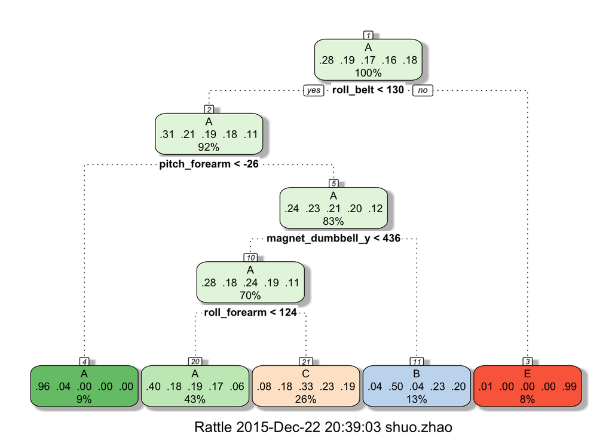

```r
dt_fit <- train(classe ~ ., data = training,
                method = 'rpart', trControl = trainCtl)
pred <- predict(dt_fit, testing[, -53])
dt_cm <- confusionMatrix(pred, testing$classe)
fancyRpartPlot(dt_fit$finalModel)
```

- Decision Tree Model Summary

```
## CART
##
## 13737 samples
##    52 predictor
##     5 classes: 'A', 'B', 'C', 'D', 'E'
##
## No pre-processing
## Resampling: Cross-Validated (10 fold)
## Summary of sample sizes: 12363, 12364, 12363, 12365, 12365, 12364, ...
## Resampling results across tuning parameters:
##
##   cp          Accuracy   Kappa       Accuracy SD  Kappa SD
##   0.03214322  0.5105218  0.36076589  0.01717664   0.02290287
##   0.05991252  0.4390913  0.24792518  0.06291006   0.10628585
##   0.11524769  0.3229192  0.05878121  0.04099320   0.06227627
##
## Accuracy was used to select the optimal model using  the largest value.
## The final value used for the model was cp = 0.03214322.
```

- Decision Tree Test Result

```
## Confusion Matrix and Statistics
##
##           Reference
## Prediction    A    B    C    D    E
##          A 1535  514  472  428  160
##          B   25  379   32  174  143
##          C  110  246  522  362  291
##          D    0    0    0    0    0
##          E    4    0    0    0  488
##
## Overall Statistics
##
##                Accuracy : 0.4969
##                  95% CI : (0.484, 0.5097)
##     No Information Rate : 0.2845
##     P-Value [Acc > NIR] : < 2.2e-16
##
##                   Kappa : 0.3416
##  Mcnemar's Test P-Value : NA
##
## Statistics by Class:
##
##                      Class: A Class: B Class: C Class: D Class: E
## Sensitivity            0.9170   0.3327   0.5088   0.0000  0.45102
## Specificity            0.6262   0.9212   0.7923   1.0000  0.99917
## Pos Pred Value         0.4937   0.5033   0.3410      NaN  0.99187
## Neg Pred Value         0.9499   0.8519   0.8842   0.8362  0.88986
## Prevalence             0.2845   0.1935   0.1743   0.1638  0.18386
## Detection Rate         0.2608   0.0644   0.0887   0.0000  0.08292
## Detection Prevalence   0.5283   0.1280   0.2602   0.0000  0.08360
## Balanced Accuracy      0.7716   0.6270   0.6506   0.5000  0.72509
```

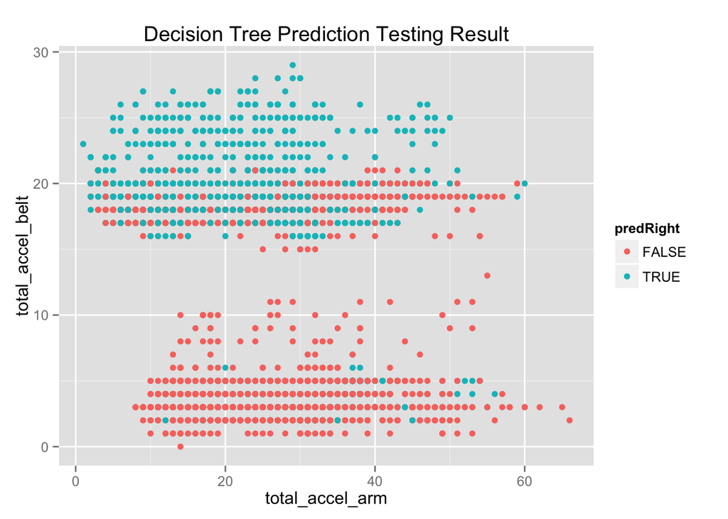

#### Expected and Estimated out of sample error rate

- Decision Tree model dones’t have great accuracy, according to the model summary I expect its in sample error rate to be around 50%.
- Base on the training model and confusion matrix testing result
  - The actual out of sample error rate from cross-validation is: 0.503
  - The Accuracy with 95% confidence interval (0.484, 0.51)

### Random Forest Model

- I use random forest as my second model due to it has great accuracy.

```r
rf_fit <- train(classe ~ ., data = training, method = 'rf',
                prox = TRUE, trControl = trainCtl)
pred <- predict(rf_fit, testing[, -53])
rf_cm <- confusionMatrix(pred, testing$classe)
```

- Random Forest Model Summary

```
##
## Call:
##  randomForest(x = x, y = y, mtry = param$mtry, proximity = TRUE)
##                Type of random forest: classification
##                      Number of trees: 500
## No. of variables tried at each split: 2
##
##         OOB estimate of  error rate: 0.76%
## Confusion matrix:
##      A    B    C    D    E class.error
## A 3902    2    1    0    1 0.001024066
## B   22 2630    6    0    0 0.010534236
## C    0   16 2376    4    0 0.008347245
## D    0    0   45 2204    3 0.021314387
## E    0    0    0    5 2520 0.001980198
```

- Random Forest Test Result

```
## Confusion Matrix and Statistics
##
##           Reference
## Prediction    A    B    C    D    E
##          A 1673    4    0    0    0
##          B    1 1132    7    0    0
##          C    0    3 1019   18    0
##          D    0    0    0  945    1
##          E    0    0    0    1 1081
##
## Overall Statistics
##
##                Accuracy : 0.9941
##                  95% CI : (0.9917, 0.9959)
##     No Information Rate : 0.2845
##     P-Value [Acc > NIR] : < 2.2e-16
##
##                   Kappa : 0.9925
##  Mcnemar's Test P-Value : NA
##
## Statistics by Class:
##
##                      Class: A Class: B Class: C Class: D Class: E
## Sensitivity            0.9994   0.9939   0.9932   0.9803   0.9991
## Specificity            0.9991   0.9983   0.9957   0.9998   0.9998
## Pos Pred Value         0.9976   0.9930   0.9798   0.9989   0.9991
## Neg Pred Value         0.9998   0.9985   0.9986   0.9962   0.9998
## Prevalence             0.2845   0.1935   0.1743   0.1638   0.1839
## Detection Rate         0.2843   0.1924   0.1732   0.1606   0.1837
## Detection Prevalence   0.2850   0.1937   0.1767   0.1607   0.1839
## Balanced Accuracy      0.9992   0.9961   0.9944   0.9900   0.9994
```

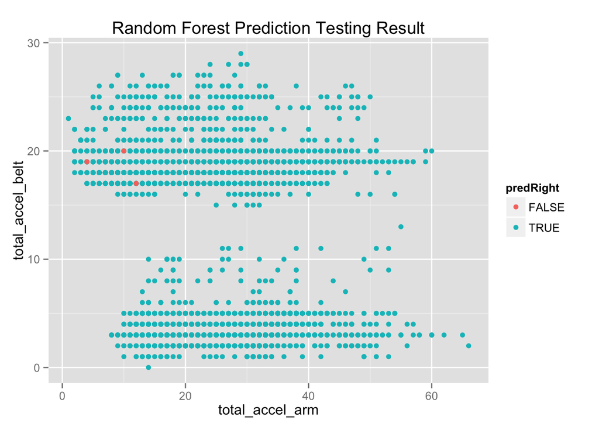

#### Expected and Estimated out of sample error rate

- Due to the random forest model always has good accuracy, and according to the model’s OOB estimate of error rate, it’s expected to be around 0.7%.
- Base on the training model and confusion matrix testing result
  - The actual out of sample error rate from cross-validation is: 0.006
  - The Accuracy with 95% confidence interval (0.992, 0.996)

### Boosting with GBM Model

- In the third model, I use gbm model. It’s a kind of boosting with trees model.

```r
gbm_fit <- train(classe ~ ., method = "gbm", data = training,
                 verbose = FALSE, trControl = trainCtl)
pred <- predict(gbm_fit, testing[, -53])
gbm_cm <- confusionMatrix(pred, testing$classe)
```

- GBM Model Summary

```
## Stochastic Gradient Boosting
##
## 13737 samples
##    52 predictor
##     5 classes: 'A', 'B', 'C', 'D', 'E'
##
## No pre-processing
## Resampling: Cross-Validated (10 fold)
## Summary of sample sizes: 12363, 12364, 12364, 12364, 12364, 12361, ...
## Resampling results across tuning parameters:
##
##   interaction.depth  n.trees  Accuracy   Kappa      Accuracy SD
##   1                   50      0.7514004  0.6847952  0.014844121
##   1                  100      0.8193219  0.7713606  0.011034954
##   1                  150      0.8547724  0.8161970  0.007163998
##   2                   50      0.8569545  0.8187374  0.010852949
##   2                  100      0.9060918  0.8811485  0.008000683
##   2                  150      0.9306986  0.9122913  0.004261716
##   3                   50      0.8978676  0.8707105  0.007790999
##   3                  100      0.9436563  0.9287000  0.004588259
##   3                  150      0.9619283  0.9518343  0.004702261
##   Kappa SD
##   0.018505257
##   0.013812502
##   0.008990295
##   0.013686741
##   0.010125616
##   0.005391347
##   0.009868153
##   0.005796550
##   0.005943159
##
## Tuning parameter 'shrinkage' was held constant at a value of 0.1
##
## Tuning parameter 'n.minobsinnode' was held constant at a value of 10
## Accuracy was used to select the optimal model using  the largest value.
## The final values used for the model were n.trees = 150,
##  interaction.depth = 3, shrinkage = 0.1 and n.minobsinnode = 10.
```

- GBM Model Test Result by confusion matrix

```
## Confusion Matrix and Statistics
##
##           Reference
## Prediction    A    B    C    D    E
##          A 1656   40    0    3    5
##          B    8 1068   34    3    9
##          C    8   31  982   39    3
##          D    2    0    7  911   20
##          E    0    0    3    8 1045
##
## Overall Statistics
##
##                Accuracy : 0.9621
##                  95% CI : (0.9569, 0.9668)
##     No Information Rate : 0.2845
##     P-Value [Acc > NIR] : < 2.2e-16
##
##                   Kappa : 0.952
##  Mcnemar's Test P-Value : 7.198e-12
##
## Statistics by Class:
##
##                      Class: A Class: B Class: C Class: D Class: E
## Sensitivity            0.9892   0.9377   0.9571   0.9450   0.9658
## Specificity            0.9886   0.9886   0.9833   0.9941   0.9977
## Pos Pred Value         0.9718   0.9519   0.9238   0.9691   0.9896
## Neg Pred Value         0.9957   0.9851   0.9909   0.9893   0.9923
## Prevalence             0.2845   0.1935   0.1743   0.1638   0.1839
## Detection Rate         0.2814   0.1815   0.1669   0.1548   0.1776
## Detection Prevalence   0.2895   0.1907   0.1806   0.1597   0.1794
## Balanced Accuracy      0.9889   0.9631   0.9702   0.9696   0.9818
```

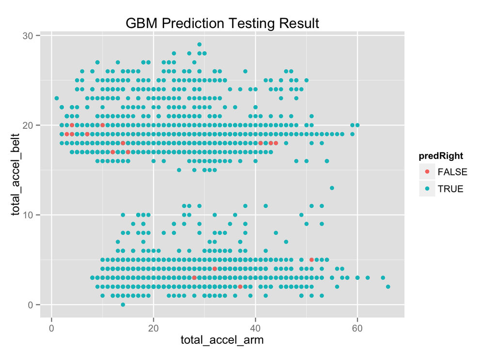

### Model Comparison

[output not shown]

- Compare all 3 models, Random Forests is the best model in this case. It has the best accuracy and kappa value.

## Test Cases Submission

```r
testing_set <- read.csv('pml-testing.csv', na.strings=c("NA","#DIV/0!",""))
result <- predict(rf_fit, testing_set)
result
```

```
##  [1] B A B A A E D B A A B C B A E E A B B B
## Levels: A B C D E
```

```r
pml_write_files = function(x){
  n = length(x)
  for(i in 1:n){
    filename = paste0("problem_id_",i,".txt")
    write.table(x[i],file=filename,quote=FALSE,row.names=FALSE,col.names=FALSE)
  }
}

pml_write_files(result)
```

## References

[1] Velloso, E.; Bulling, A.; Gellersen, H.; Ugulino, W.; Fuks, H. Qualitative Activity Recognition of Weight Lifting Exercises. Proceedings of 4th International Conference in Cooperation with SIGCHI (Augmented Human ’13) . Stuttgart, Germany: ACM SIGCHI, 2013.